# Homework 4&5 solutions

## Q5

There are five groups in total. The number of pounds that each person lost by following one of the four diets were recorded. Each of these 5 groups are blocks. This is a RBD (Randomized Block Design) Diet types 1,2,3 & 4 are treatments

```r
#number of treatments
k <- 4
#number of blocks
b <- 5
#treatment-means
#treatment mean for diet 1, and so on
x_trt1 <- 6.2
x_trt2 <- 8.0
x_trt3 <- 10.8
x_trt4 <- 8.2

#block means
#block mean for first block, second block and so on
x_b1 <- 5.25
x_b2 <- 7.25
x_b3 <- 7.25
x_b4 <- 10.25
x_b5 <- 11.50

#grand-mean
x_bar <- ((x_b1+x_b2+x_b3+x_b4+x_b5)*4)/20
# OR x_bar <- ((x_trt1+x_trt2+x_trt3+x_trt4)*5)/20
print('grand mean:')
```

```
## [1] "grand mean:"
```

```r
x_bar
```

```
## [1] 8.3
```

```r
#Sum of Squares for the given RBD
SST <- 5*((x_trt1-x_bar)^2+(x_trt2-x_bar)^2 +(x_trt3-x_bar)^2 +
            (x_trt4-x_bar)^2)
SSB <- 4*((x_b1-x_bar)^2+(x_b2-x_bar)^2+(x_b3-x_bar)^3+
            (x_b4-x_bar)^2+(x_b5-x_bar)^2)
SSE <- (5 - x_trt1 - x_b1 + x_bar)^2 +
       (4 - x_trt1 - x_b2 + x_bar)^2 +
       (6 - x_trt1 - x_b3 + x_bar)^2 +
       (7 - x_trt1 - x_b4 + x_bar)^2 +
       (9 - x_trt1 - x_b5 + x_bar)^2 +
       (2 - x_trt2 - x_b1 + x_bar)^2 +
       (7 - x_trt2 - x_b2 + x_bar)^2 +
       (12 - x_trt2 - x_b3 + x_bar)^2 +
       (11 - x_trt2 - x_b4 + x_bar)^2 +
       (8 - x_trt2 - x_b5 + x_bar)^2 +
       (6 - x_trt3 - x_b1 + x_bar)^2 +
       (8 - x_trt3 - x_b2 + x_bar)^2 +
       (9 - x_trt3 - x_b3 + x_bar)^2 +
       (16 - x_trt3 - x_b4 + x_bar)^2 +
       (15 - x_trt3 - x_b5 + x_bar)^2 +
       (8 - x_trt4 - x_b1 + x_bar)^2 +
       (10 - x_trt4 - x_b2 + x_bar)^2 +
       (2 - x_trt4 - x_b3 + x_bar)^2 +
       (7 - x_trt4 - x_b4 + x_bar)^2 +
       (14 - x_trt4 - x_b5 + x_bar)^2

# Mean Squares for RBD
MST <- SST/(k-1)
MST
```

```
## [1] 17.93333
```

```r
MSB <- SSB/(b-1)
MSB
```

```
## [1] 23.28987
```

```r
MSE <- SSE/((b*k)-b-k+1)
MSE
```

```
## [1] 10.85
```

For treatment Effect: - $H_{0}$ : $*{1} =* {2}= *3 =*{4} $ - $H_{a}$ : Atleast one of $\mu_{1}$,$\mu_{2}$,$\mu_3$,$\mu_{4}$ is different For Block Effect: - $H_{0}$ : $*{1}=*{2}=*3 =*{4}=_5 $ - $H_{a}$ : Atleast one of $\delta_{1},\delta_{2},\delta_3,\delta_{4},\delta_5$ is different

```r
#Test Treatment Effect
F_trt <-MST/MSE
F_trt
```

```
## [1] 1.652842
```

```r
#Compute corresponding p-value
pf(q=F_trt, df1=3, df2=12, lower.tail=FALSE)
```

```
## [1] 0.2296292
```

```r
#Or compute the F statistic for alpha=0.01 and degrees of freedom using df()
qf(0.01,3,12,lower.tail=FALSE)
```

```
## [1] 5.952545
```

```r
#Test Block Effect
F_Block <- MSB/MSE
F_Block
```

```
## [1] 2.146532
```

```r
#Compute corresponding p-value
pf(q=F_Block, df1=4, df2=12, lower.tail=FALSE)
```

```
## [1] 0.1374097
```

```r
#Or compute the F statistic for alpha=0.01 and degrees of freedom using df()
qf(0.01,4,12,lower.tail=FALSE)
```

```
## [1] 5.411951
```

Since, F_Block<f-statistic(alpha=0.01,4,12) & p-value >0.01 =>failed to reject $H_{0}$ for *block effect* Similarly, F_trt<f-statistic(alpha=0.01,3,12) & p-value>0.01=>failed to reject $H_{0}$ for *treatment effect* At 1% significance level, we lack evidence to support our claim that there is a difference among the four diets both treatment effect and block effect. From my analysis, I think this design was not sound enough because there is no block effect which means there was no additional value added to our analysis by creating blocks -> blocks were not meaningful

## Q6

The experimental design used is a one-factor randomized block design Factor is the type of graduate Levels are business, art and science graduate Block is group of the 3 graduates with similar educational and working experience

For treatment Effect (graduate type):  
- $H_{0}$ : $*{bu} =* {art}= _{sci} $  
- $H_{a}$ : Atleast one of $\mu_{bu}$,$\mu_{art}$,$\mu_{sci}$ is different

For Block Effect:  
- $H_{0}$ : $*{1}=*{2}=*3 =….=*{20} $ - $H_{a}$ : Atleast one of $\delta_{1},\delta_{2},\delta_3,..\delta_{20}$ is different

```r
#The dataset provided is not stacked format
q6 <- read.csv('Question6.csv')

#Reloading the same data in stacked format
q6 <- read.csv('Question6_stacked.csv')
#View(q6)

Sales <- q6$Sales
Grad <- factor(q6$Graduate)
Group <- factor(q6$Group)

#Check for normality
#Creating a residual plot
model <- lm(Sales ~ Grad + Group)
resids <- residuals(model)

nortest::ad.test(resids)
```

```
##
##  Anderson-Darling normality test
##
## data:  resids
## A = 0.23463, p-value = 0.7838
```

```r
shapiro.test(resids)
```

```
##
##  Shapiro-Wilk normality test
##
## data:  resids
## W = 0.99054, p-value = 0.9242
```

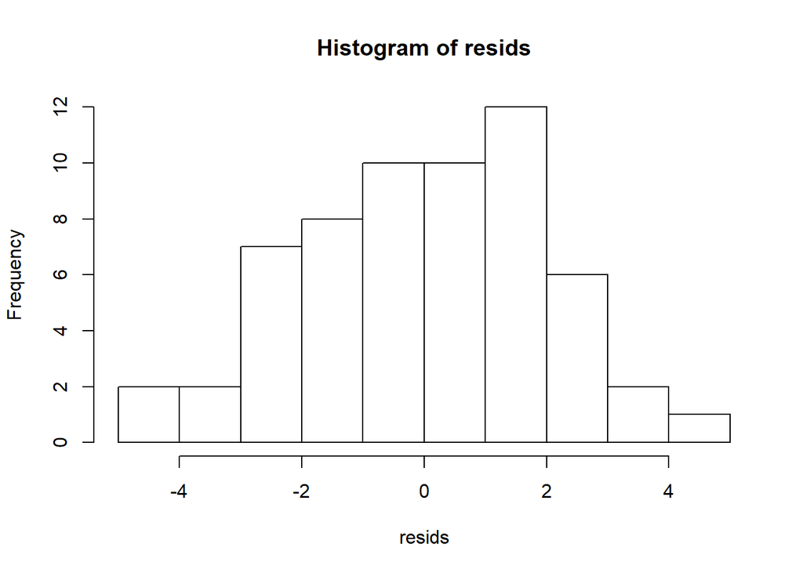

```r
hist(resids)
```

```r
#p-value>>0.05-satisfies normality
#Histogram also resembles close to normal distribution like plot

#Check for variance
car::leveneTest(Sales ~ Grad)
```

```
## Levene's Test for Homogeneity of Variance (center = median)
##       Df F value Pr(>F)
## group  2  0.4146 0.6626
##       57
```

```r
car::leveneTest(Sales ~ Group)
```

```
## Levene's Test for Homogeneity of Variance (center = median)
##       Df F value Pr(>F)
## group 19   0.456 0.9658
##       40
```

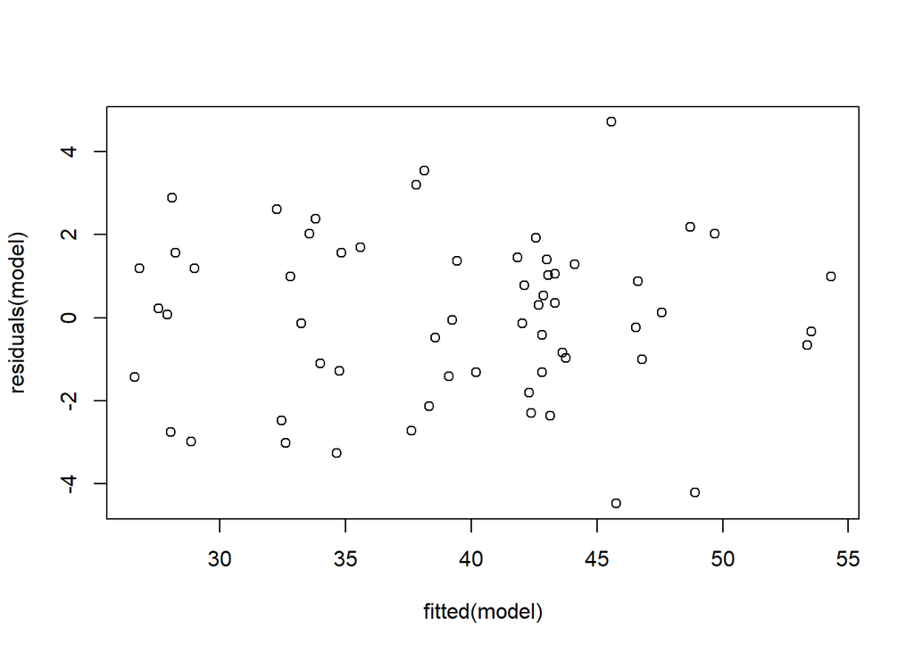

```r
#Plot for variance test
plot(fitted(model), residuals(model))
```

```r
#p-value >>0.05 for both formal tests-> constant variance is maintained
#Visual anlaysis also shows approx. constant variance throughout

#Both normality and variance tests have been cleared
#Now we proceed with ANOVA for RBD

ANOVA6 <- aov(Sales ~ Grad + Group)
summary(ANOVA6)
```

```
##             Df Sum Sq Mean Sq F value  Pr(>F)
## Grad         2   10.3    5.13    0.86   0.431
## Group       19 3020.3  158.96   26.64 2.4e-16 ***
## Residuals   38  226.7    5.97
## ---
## Signif. codes:  0 '***' 0.001 '**' 0.01 '*' 0.05 '.' 0.1 ' ' 1
```

```r
TukeyHSD(ANOVA6, which = 'Grad', ordered = TRUE)
```

```
##   Tukey multiple comparisons of means
##     95% family-wise confidence level
##     factor levels have been ordered
##
## Fit: aov(formula = Sales ~ Grad + Group)
##
## $Grad
##                   diff        lwr      upr     p adj
## Science-Arts     0.185 -1.6987645 2.068764 0.9688969
## Business-Arts    0.955 -0.9287645 2.838764 0.4395209
## Business-Science 0.770 -1.1137645 2.653764 0.5833203
```

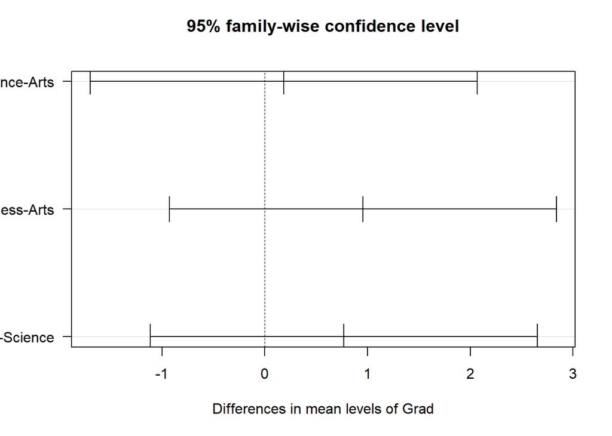

```r
plot(TukeyHSD(ANOVA6, which = 'Grad', ordered = TRUE), las = 1)
```

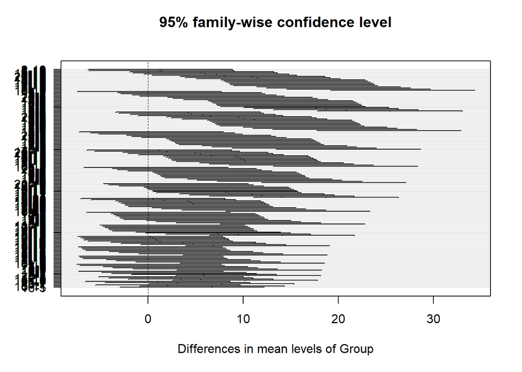

```r
#TukeyHSD(ANOVA6, which = 'Group', ordered = TRUE) --too long a table

plot(TukeyHSD(ANOVA6, which = 'Group', ordered = TRUE), las = 1) #to give a visual idea
```

*a.* As, p-value for treatment effect > 0.05 => Failed to reject $H_{0}$ At 5% significance level, we don’t have sufficient evidence to conclude that there are differences in sales ability between the holders of different graduation types As, p-value for block effect << 0.05 => Reject $H_{0}$ There is a significant difference between the average of sales ability among blocks (groups 1-20) At 5% significance level, we have sufficient evidence to conclude that there are differences in sales ability between employees with different working and educational experience

*b* As Block effect turned out to be significant as mentioned above p-value<<0.05 Thus, blocks were meaningful RBD was a good experiment design selected for this analysis

```r
#One factor ANOVA with graduate types
ANOVA6 <- aov(Sales ~ Grad)
summary(ANOVA6)
```

```
##             Df Sum Sq Mean Sq F value Pr(>F)
## Grad         2     10    5.13    0.09  0.914
## Residuals   57   3247   56.97
```

*c.* Required consitions to conduct test in part a. As seen in the analysis done above, For Normality: a.Plotted a Histogram b.Conducted following formal tests-> Anderson-Darling test, Shapiro-Wilk test For Constant Variance: a.Levene’sTest of Equality of Variances  
b.Plot residuals and predicted values

All these tests were passed, As a result of which we conducted one-factor RBD Anova test